# Принятие бизнес-решения на основе оценки результатов A/B-теста.

**Цель проекта:** проверка гипотез для увеличения выручки.

Результаты выполнения проекта, в случае подтверждения одной или нескольких гипотез, позволят увеличить выручку интернет-магазина.

**Задача проекта:** Проранжировать гипотезы в порядке приоритета, запустить A/B-тест и проанализировать полученные результаты.

**Исходные данные** — это данные интернет-магазина о заказах пользователей и их посещениях. Также имеется файл c предварительными 10-бальными оценками зафиксированных гипотез (по критериям: Reach, Impact, Confidence, Efforts)

### 1. Изучение данных и их подготовка к анализу

Загружаем данные о гипотезах, заказах и посещениях сайта из CSV-файлов в переменные.

Имеем файлы

```
     - *оценка гипотез по критериям:* hypothesis.csv;
     - *заказы:* orders.csv;
     - *посещения:* visitors.csv.
```

Изучим данные и выполним предобработку. Проверим наличие в данных пропусков и дубликатов. Убедимся, что типы данных во всех колонках соответствуют сохранённым в них значениям. Особое внимание на столбцы с датой и временем.

```python
import pandas as pd
import matplotlib.pyplot as plt
import seaborn as sns
sns.set_style("darkgrid")
import datetime as dt
import numpy as np
import scipy.stats as stats
from IPython.display import display
```

```python
hypothesis, orders, visits = (
  pd.read_csv("C:\\Users\\user\\Desktop\\Projects\\9\\hypothesis.csv"),  # оценка гипотез по критериям
  pd.read_csv("C:\\Users\\user\\Desktop\\Projects\\9\\orders.csv"),  # заказы
  pd.read_csv("C:\\Users\\user\\Desktop\\Projects\\9\\visitors.csv"),  # посещения сайта
)

pd.set_option('display.max_colwidth', None)#для вывода на экран всего текста гипотез без усечения

display(hypothesis)
display(orders.head())
display(visits.head())
```

|  | Hypothesis | Reach | Impact | Confidence | Efforts |
| --- | --- | --- | --- | --- | --- |
| 0 | Добавить два новых канала привлечения трафика, что позволит привлекать на 30% больше пользователей | 3 | 10 | 8 | 6 |
| 1 | Запустить собственную службу доставки, что сократит срок доставки заказов | 2 | 5 | 4 | 10 |
| 2 | Добавить блоки рекомендаций товаров на сайт интернет магазина, чтобы повысить конверсию и средний чек заказа | 8 | 3 | 7 | 3 |
| 3 | Изменить структура категорий, что увеличит конверсию, т.к. пользователи быстрее найдут нужный товар | 8 | 3 | 3 | 8 |
| 4 | Изменить цвет фона главной страницы, чтобы увеличить вовлеченность пользователей | 3 | 1 | 1 | 1 |
| 5 | Добавить страницу отзывов клиентов о магазине, что позволит увеличить количество заказов | 3 | 2 | 2 | 3 |
| 6 | Показать на главной странице баннеры с актуальными акциями и распродажами, чтобы увеличить конверсию | 5 | 3 | 8 | 3 |
| 7 | Добавить форму подписки на все основные страницы, чтобы собрать базу клиентов для email-рассылок | 10 | 7 | 8 | 5 |
| 8 | Запустить акцию, дающую скидку на товар в день рождения | 1 | 9 | 9 | 5 |

|  | transactionId | visitorId | date | revenue | group |
| --- | --- | --- | --- | --- | --- |
| 0 | 3667963787 | 3312258926 | 2019-08-15 | 1650 | B |
| 1 | 2804400009 | 3642806036 | 2019-08-15 | 730 | B |
| 2 | 2961555356 | 4069496402 | 2019-08-15 | 400 | A |
| 3 | 3797467345 | 1196621759 | 2019-08-15 | 9759 | B |
| 4 | 2282983706 | 2322279887 | 2019-08-15 | 2308 | B |

|  | date | group | visitors |
| --- | --- | --- | --- |
| 0 | 2019-08-01 | A | 719 |
| 1 | 2019-08-02 | A | 619 |
| 2 | 2019-08-03 | A | 507 |
| 3 | 2019-08-04 | A | 717 |
| 4 | 2019-08-05 | A | 756 |

```python
print('Дубликатов в гипотезах:', hypothesis.duplicated().sum()) #Проверим наличие дубликатов строк
print('Дубликатов заказов:', orders.duplicated().sum())
print('Дубликатов посещений:', visits.duplicated().sum())

hypothesis.columns=hypothesis.columns.str.lower() #переводим названия столбцов в нижний регистр
orders.columns=orders.columns.str.lower()
print('_'*25, 'hypothesis info:', '_'*25)
hypothesis.info() # изучим информацию о типах данных в столбцах и размере датафрейма, возможных пропусках в данных
hypothesis.describe() #попытаемся понять, есть ли аномальные значения
```

```
Дубликатов в гипотезах: 0
Дубликатов заказов: 0
Дубликатов посещений: 0
_________________________ hypothesis info: _________________________
<class 'pandas.core.frame.DataFrame'>
RangeIndex: 9 entries, 0 to 8
Data columns (total 5 columns):
 #   Column      Non-Null Count  Dtype
---  ------      --------------  -----
 0   hypothesis  9 non-null      object
 1   reach       9 non-null      int64
 2   impact      9 non-null      int64
 3   confidence  9 non-null      int64
 4   efforts     9 non-null      int64
dtypes: int64(4), object(1)
memory usage: 488.0+ bytes
```

|  | reach | impact | confidence | efforts |
| --- | --- | --- | --- | --- |
| count | 9.000000 | 9.000000 | 9.000000 | 9.000000 |
| mean | 4.777778 | 4.777778 | 5.555556 | 4.888889 |
| std | 3.153481 | 3.192874 | 3.045944 | 2.803767 |
| min | 1.000000 | 1.000000 | 1.000000 | 1.000000 |
| 25% | 3.000000 | 3.000000 | 3.000000 | 3.000000 |
| 50% | 3.000000 | 3.000000 | 7.000000 | 5.000000 |
| 75% | 8.000000 | 7.000000 | 8.000000 | 6.000000 |
| max | 10.000000 | 10.000000 | 9.000000 | 10.000000 |

```python
print('_'*25, 'orders info:', '_'*25)
orders.info() # изучим информацию о типах данных в столбцах и размере датафрейма, возможных пропусках в данных
orders['revenue'].describe().apply("{0:.3f}".format) #попытаемся понять, есть ли аномальные значения
```

```
_________________________ orders info: _________________________
<class 'pandas.core.frame.DataFrame'>
RangeIndex: 1197 entries, 0 to 1196
Data columns (total 5 columns):
 #   Column         Non-Null Count  Dtype
---  ------         --------------  -----
 0   transactionid  1197 non-null   int64
 1   visitorid      1197 non-null   int64
 2   date           1197 non-null   object
 3   revenue        1197 non-null   int64
 4   group          1197 non-null   object
dtypes: int64(3), object(2)
memory usage: 46.9+ KB
```

```
count       1197.000
mean        8348.006
std        39191.132
min           50.000
25%         1220.000
50%         2978.000
75%         8290.000
max      1294500.000
Name: revenue, dtype: object
```

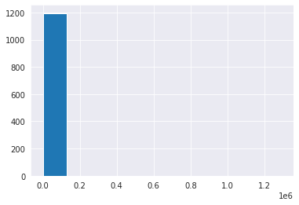

```python
plt.hist(orders['revenue']);# строим общую гистограмму для всех сумм заказов range(0,1240000)
```

Распределение по сумме заказов необходимо рассмотреть без выбросов, т.к. с выбросами основная часть данных попадает в одну корзину.

```python
print('_'*25, 'visits info:', '_'*25)
visits.info() # изучим информацию о типах данных в столбцах и размере датафрейма, возможных пропусках в данных
visits.describe() #попытаемся понять, есть ли аномальные значения
```

```
_________________________ visits info: _________________________
<class 'pandas.core.frame.DataFrame'>
RangeIndex: 62 entries, 0 to 61
Data columns (total 3 columns):
 #   Column    Non-Null Count  Dtype
---  ------    --------------  -----
 0   date      62 non-null     object
 1   group     62 non-null     object
 2   visitors  62 non-null     int64
dtypes: int64(1), object(2)
memory usage: 1.6+ KB
```

|  | visitors |
| --- | --- |
| count | 62.000000 |
| mean | 607.290323 |
| std | 114.400560 |
| min | 361.000000 |
| 25% | 534.000000 |
| 50% | 624.500000 |
| 75% | 710.500000 |
| max | 770.000000 |